# Practica Preparacion de datos en R, Jurjen

```r
options(warn = 0)
warning = F
```

```r
library(data.table)
library(dplyr)
```

```r
library(corrplot)
library(lattice)
library(caret)
library('RANN')
library(knitr)
library(outliers)
```

# 1. Leer los datos del fichero csv y observar su distribucion

## 1.1 Load data into a data.table

```r
cs.training <- fread("../dat/cs-training.csv", stringsAsFactors = FALSE)
cs.test <- fread("../dat/cs-test.csv", stringsAsFactors = FALSE)
```

## 1.2 Look at the data set

```r
dim(cs.training)   # There are 150k obs. in the training set
```

```
## [1] 150000     12
```

```r
dim(cs.test)   # There are 101.5k obs. in the test set
```

```
## [1] 101503     12
```

```r
str(cs.training)   # Look at a sample to see what's going on
```

```
## Classes 'data.table' and 'data.frame':   150000 obs. of  12 variables:
##  $ V1                                  : int  1 2 3 4 5 6 7 8 9 10 ...
##  $ SeriousDlqin2yrs                    : int  1 0 0 0 0 0 0 0 0 0 ...
##  $ RevolvingUtilizationOfUnsecuredLines: num  0.766 0.957 0.658 0.234 0.907 ...
##  $ age                                 : int  45 40 38 30 49 74 57 39 27 57 ...
##  $ NumberOfTime30-59DaysPastDueNotWorse: int  2 0 1 0 1 0 0 0 0 0 ...
##  $ DebtRatio                           : num  0.803 0.1219 0.0851 0.036 0.0249 ...
##  $ MonthlyIncome                       : int  9120 2600 3042 3300 63588 3500 NA 3500 NA 23684 ...
##  $ NumberOfOpenCreditLinesAndLoans     : int  13 4 2 5 7 3 8 8 2 9 ...
##  $ NumberOfTimes90DaysLate             : int  0 0 1 0 0 0 0 0 0 0 ...
##  $ NumberRealEstateLoansOrLines        : int  6 0 0 0 1 1 3 0 0 4 ...
##  $ NumberOfTime60-89DaysPastDueNotWorse: int  0 0 0 0 0 0 0 0 0 0 ...
##  $ NumberOfDependents                  : int  2 1 0 0 0 1 0 0 NA 2 ...
##  - attr(*, ".internal.selfref")=<externalptr>
```

```r
glimpse(cs.training)   # Nicer version of str
```

```
## Observations: 150,000
## Variables: 12
## $ V1                                     <int> 1, 2, 3, 4, 5, 6, 7, 8,...
## $ SeriousDlqin2yrs                       <int> 1, 0, 0, 0, 0, 0, 0, 0,...
## $ RevolvingUtilizationOfUnsecuredLines   <dbl> 0.76612661, 0.95715102,...
## $ age                                    <int> 45, 40, 38, 30, 49, 74,...
## $ `NumberOfTime30-59DaysPastDueNotWorse` <int> 2, 0, 1, 0, 1, 0, 0, 0,...
## $ DebtRatio                              <dbl> 8.029821e-01, 1.218762e...
## $ MonthlyIncome                          <int> 9120, 2600, 3042, 3300,...
## $ NumberOfOpenCreditLinesAndLoans        <int> 13, 4, 2, 5, 7, 3, 8, 8...
## $ NumberOfTimes90DaysLate                <int> 0, 0, 1, 0, 0, 0, 0, 0,...
## $ NumberRealEstateLoansOrLines           <int> 6, 0, 0, 0, 1, 1, 3, 0,...
## $ `NumberOfTime60-89DaysPastDueNotWorse` <int> 0, 0, 0, 0, 0, 0, 0, 0,...
## $ NumberOfDependents                     <int> 2, 1, 0, 0, 0, 1, 0, 0,...
```

```r
View(cs.training[sample(.N, 1000)])   # Look at a sample to see what's going on
```

There are NA’s in MonthlyIncome and NumberOfDependents

```r
str(cs.test)
```

```
## Classes 'data.table' and 'data.frame':   101503 obs. of  12 variables:
##  $ V1                                  : int  1 2 3 4 5 6 7 8 9 10 ...
##  $ SeriousDlqin2yrs                    : logi  NA NA NA NA NA NA ...
##  $ RevolvingUtilizationOfUnsecuredLines: num  0.8855 0.4633 0.0433 0.2803 1 ...
##  $ age                                 : int  43 57 59 38 27 63 50 79 68 23 ...
##  $ NumberOfTime30-59DaysPastDueNotWorse: int  0 0 0 1 0 0 0 1 0 98 ...
##  $ DebtRatio                           : num  0.1775 0.5272 0.6876 0.926 0.0199 ...
##  $ MonthlyIncome                       : int  5700 9141 5083 3200 3865 4140 0 3301 NA 0 ...
##  $ NumberOfOpenCreditLinesAndLoans     : int  4 15 12 7 4 4 5 8 4 0 ...
##  $ NumberOfTimes90DaysLate             : int  0 0 0 0 0 0 0 0 0 98 ...
##  $ NumberRealEstateLoansOrLines        : int  0 4 1 2 0 0 0 1 1 0 ...
##  $ NumberOfTime60-89DaysPastDueNotWorse: int  0 0 0 0 0 0 0 0 0 98 ...
##  $ NumberOfDependents                  : int  0 2 2 0 1 1 3 1 0 0 ...
##  - attr(*, ".internal.selfref")=<externalptr>
```

**There are no labels in the test set!**

## 1.3 Changing to shorter column names & put columns in different order

```r
setnames(cs.training, c("id", "SD", "RUUL", "Age", "no3059", "DebtRatio", "Income", "OpenCredit", "no90", "REloans", "no6089", "Dep"))
cs.training = cs.training[,.(id, SD, Age, RUUL, DebtRatio, Income, OpenCredit, REloans, Dep, no3059, no6089, no90)]
```

```r
cs.training %>% head() %>% kable(row.names = FALSE)
```

| id | SD | Age | RUUL | DebtRatio | Income | OpenCredit | REloans | Dep | no3059 | no6089 | no90 |
| --- | --- | --- | --- | --- | --- | --- | --- | --- | --- | --- | --- |
| 1 | 1 | 45 | 0.7661266 | 0.8029821 | 9120 | 13 | 6 | 2 | 2 | 0 | 0 |
| 2 | 0 | 40 | 0.9571510 | 0.1218762 | 2600 | 4 | 0 | 1 | 0 | 0 | 0 |
| 3 | 0 | 38 | 0.6581801 | 0.0851134 | 3042 | 2 | 0 | 0 | 1 | 0 | 1 |
| 4 | 0 | 30 | 0.2338098 | 0.0360497 | 3300 | 5 | 0 | 0 | 0 | 0 | 0 |
| 5 | 0 | 49 | 0.9072394 | 0.0249257 | 63588 | 7 | 1 | 0 | 1 | 0 | 0 |
| 6 | 0 | 74 | 0.2131787 | 0.3756070 | 3500 | 3 | 1 | 1 | 0 | 0 | 0 |

```r
cs.training %>% tail() %>% kable(row.names = FALSE)
```

[output not shown]

## 1.4 Ratio between SeriousDlq Y/N

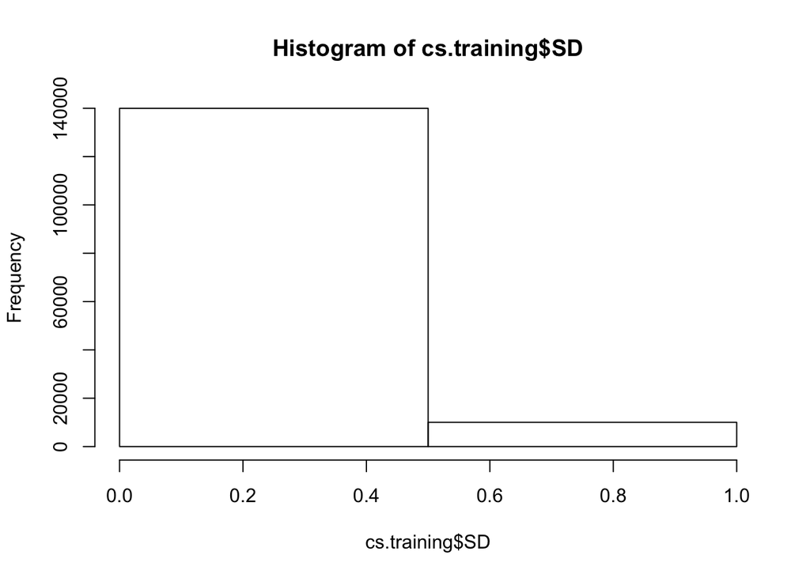

```r
hist(cs.training$SD, breaks = 2)
```

```r
prop.table(table(cs.training$SD))   # 0.933 / 0.067
```

```
##
##       0       1
## 0.93316 0.06684
```

6,7% of the training set experienced 90 days past due delinquency or worse  
**Dataset is unbalanced!**  
This is to be expected here, but can lead to problems when making predictions. I hope we will learn about this later when we get to machine learning.

## 1.5 Summary

```r
summary(cs.training)
```

```
##        id               SD               Age             RUUL
##  Min.   :     1   Min.   :0.00000   Min.   :  0.0   Min.   :    0.00
##  1st Qu.: 37501   1st Qu.:0.00000   1st Qu.: 41.0   1st Qu.:    0.03
##  Median : 75000   Median :0.00000   Median : 52.0   Median :    0.15
##  Mean   : 75000   Mean   :0.06684   Mean   : 52.3   Mean   :    6.05
##  3rd Qu.:112500   3rd Qu.:0.00000   3rd Qu.: 63.0   3rd Qu.:    0.56
##  Max.   :150000   Max.   :1.00000   Max.   :109.0   Max.   :50708.00
##
##    DebtRatio            Income          OpenCredit        REloans
##  Min.   :     0.0   Min.   :      0   Min.   : 0.000   Min.   : 0.000
##  1st Qu.:     0.2   1st Qu.:   3400   1st Qu.: 5.000   1st Qu.: 0.000
##  Median :     0.4   Median :   5400   Median : 8.000   Median : 1.000
##  Mean   :   353.0   Mean   :   6670   Mean   : 8.453   Mean   : 1.018
##  3rd Qu.:     0.9   3rd Qu.:   8249   3rd Qu.:11.000   3rd Qu.: 2.000
##  Max.   :329664.0   Max.   :3008750   Max.   :58.000   Max.   :54.000
##                     NA's   :29731
##       Dep             no3059           no6089             no90
##  Min.   : 0.000   Min.   : 0.000   Min.   : 0.0000   Min.   : 0.000
##  1st Qu.: 0.000   1st Qu.: 0.000   1st Qu.: 0.0000   1st Qu.: 0.000
##  Median : 0.000   Median : 0.000   Median : 0.0000   Median : 0.000
##  Mean   : 0.757   Mean   : 0.421   Mean   : 0.2404   Mean   : 0.266
##  3rd Qu.: 1.000   3rd Qu.: 0.000   3rd Qu.: 0.0000   3rd Qu.: 0.000
##  Max.   :20.000   Max.   :98.000   Max.   :98.0000   Max.   :98.000
##  NA's   :3924
```

! There are 30k NA’s in monthly income (20% of the data).  
There are 4k NA’s in number of dependents.  
Imputing see part 3.  
! Mean and maximum for RUUL and DebtRatio are odd values.

## 1.6 Distribucion

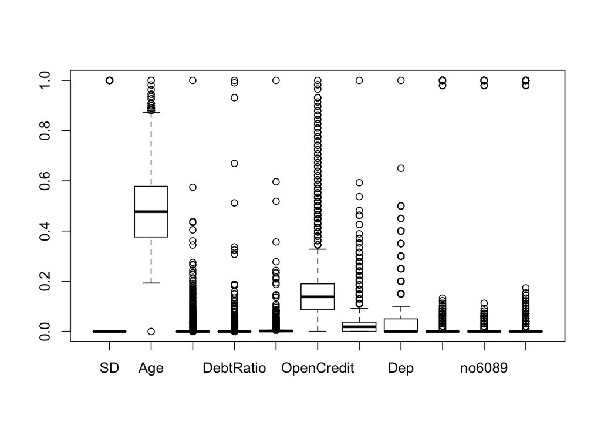

```r
colmax = sapply(cs.training[,-"id",with=F], max, na.rm=T)
normalized = scale(cs.training[,-"id",with=F], center = F, scale = colmax)
boxplot(normalized)
```

! We see that most variables have a lot of outliers (k=1.5).

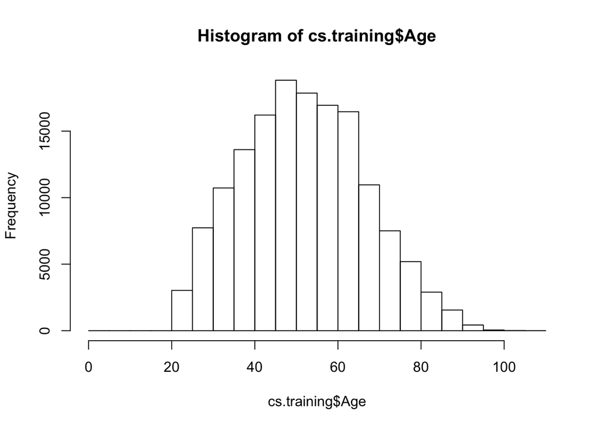

```r
hist(cs.training$Age)
```

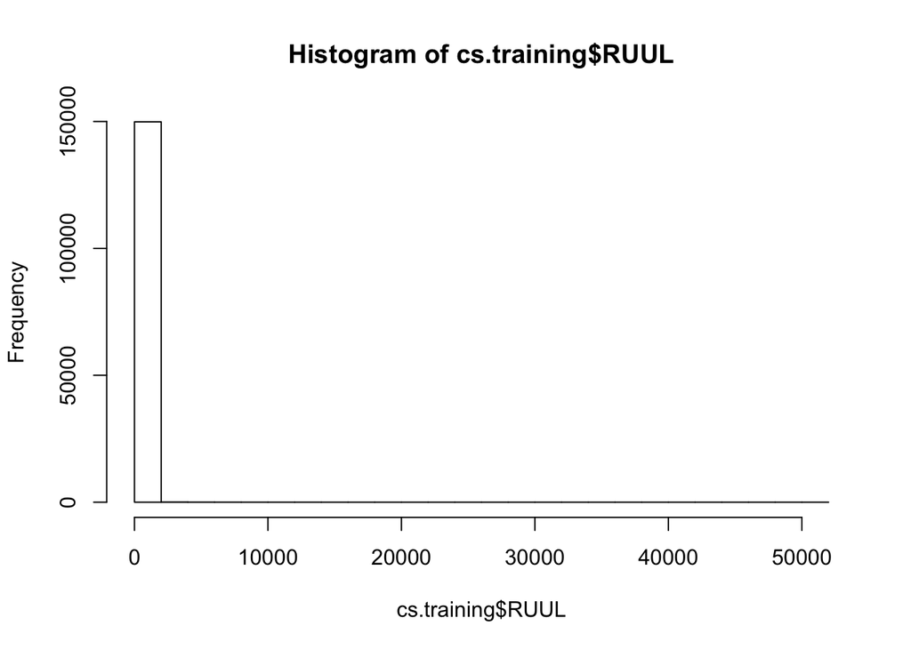

```r
hist(cs.training$RUUL)
```

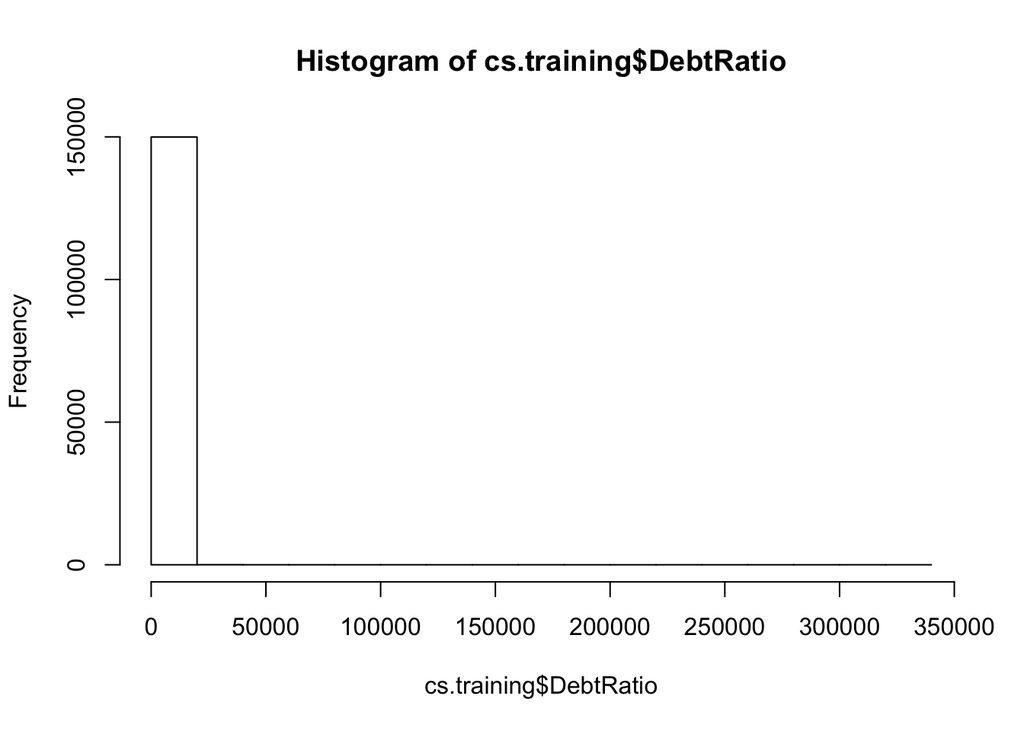

```r
hist(cs.training$DebtRatio)
```

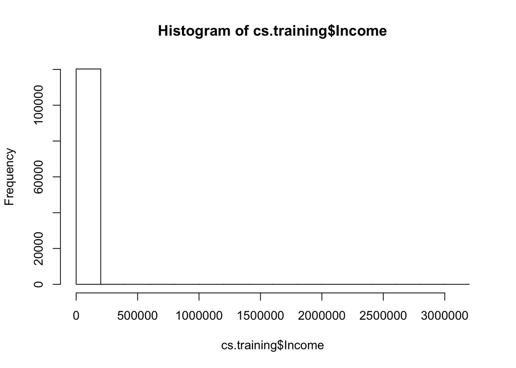

```r
hist(cs.training$Income)
```

We need to look at the distributions again after removing the outliers! See part 2.

# 2. Detectar e identificar los Outliers.

Summary (1.5) and hist (1.6) already gave us insight in the outliers.

## 2.1 Age

```r
boxplot.stats(cs.training$Age)$out
```

```
##  [1]  97  99 101  97  98  98  97  97 103  99 102  97  97  97  99 107  97
## [18]  97  98 105  99 103  99   0  97  99  99 102  98  99 101 102  97 109
## [35]  99  98  97  97 101  97  97 103  97 109  98  97
```

The value 0 must be a mistake. Let’s replace it by the mean of the age column.

```r
set(cs.training, which(cs.training$Age == 0), "Age", as.integer(mean(cs.training$Age)))
```

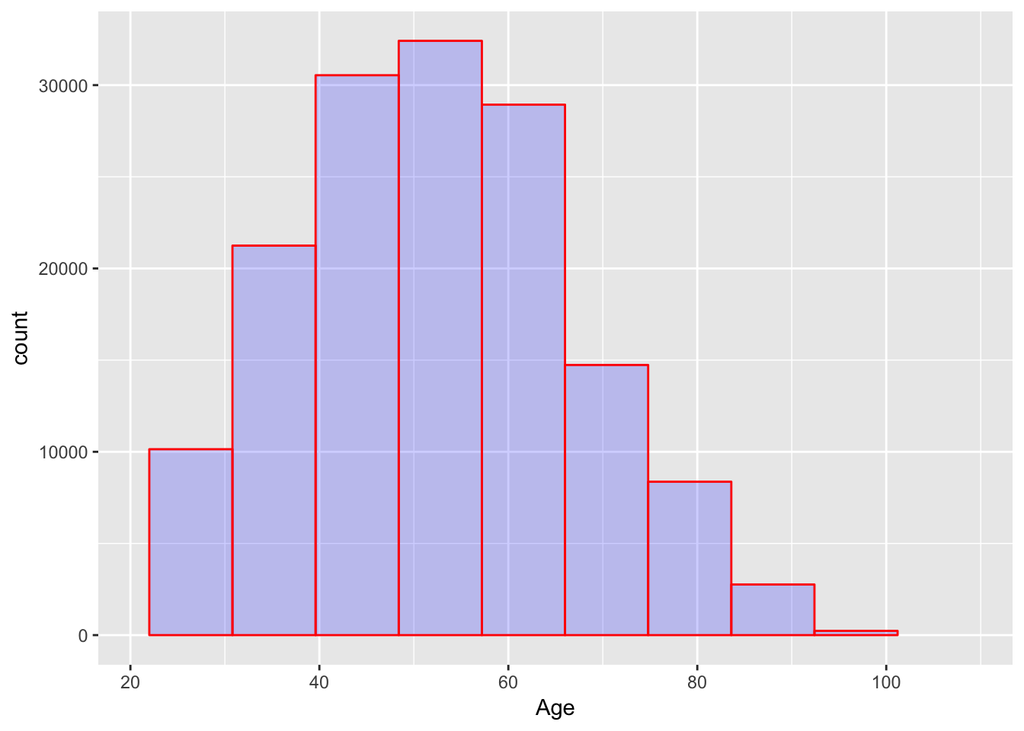

```r
qplot(data = cs.training,
      x = Age,
      geom="histogram",
      binwidth = (max(cs.training$Age)-min(cs.training$Age))/10,
      xlab = "Age",
      fill=I("blue"),
      col=I("red"),
      alpha=I(0.2),
      xlim=c(min(cs.training$Age), max(cs.training$Age)))
```

## 2.2 Revolving Utilization of Unsecured Lines

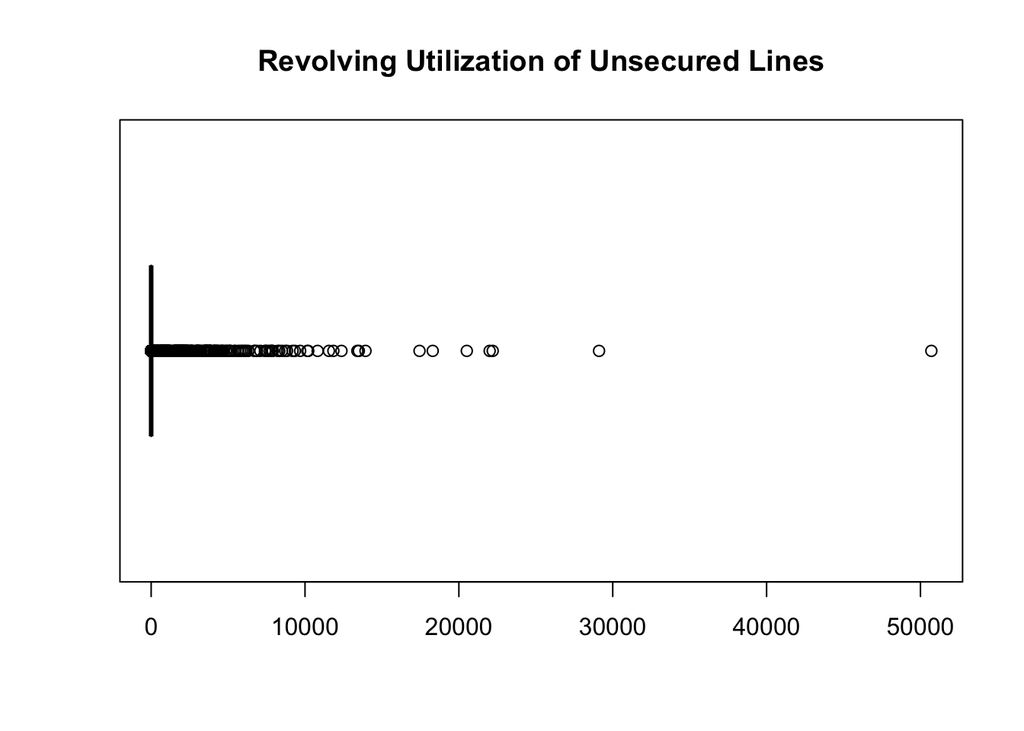

```r
boxplot(cs.training$RUUL, main="Revolving Utilization of Unsecured Lines", horizontal = T)
```

You would expect that RUUL would have of maximum around 1. But there are big outliers. Upto a value of 50.000!

```r
cor(cs.training$RUUL, cs.training$SD, use = "pairwise.complete.obs")   # -0.0018
```

```
## [1] -0.001801503
```

This doesn’t seem correct!  
You would expect a positive correlation between this variable and Serous Delinquency.

```r
RUULstats <- boxplot.stats(cs.training$RUUL)$stats
data.table(stats=c('min','lower quartile','median','upper quartile','max'),
           value=RUULstats)   %>% kable()
```

| stats | value |
| --- | --- |
| min | 0.0000000 |
| lower quartile | 0.0298669 |
| median | 0.1541807 |
| upper quartile | 0.5590484 |
| max | 1.3521595 |

```r
length(boxplot.stats(cs.training$RUUL)$out)   # 763
```

```
## [1] 763
```

RUUL has 763 outliers (out of 150.000).  
It seems a good idea to replace them with another value.

```r
outlierReplace = function(dataframe, cols, rows, newValue = NA) {
  if (any(rows)) {
    set(dataframe, rows, cols, newValue)
  }
}
```

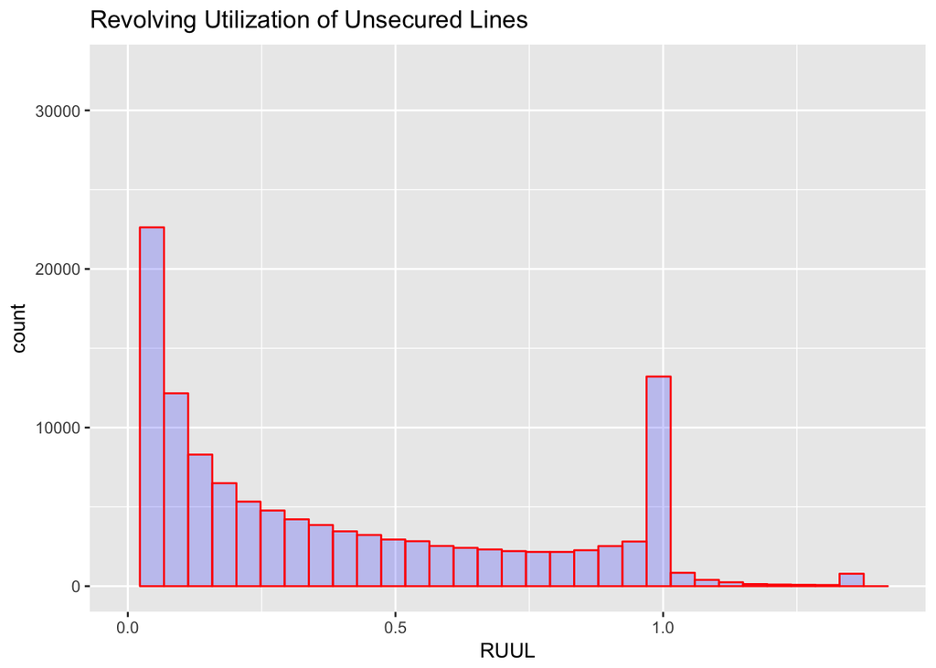

```r
outlierReplace(cs.training, "RUUL", which(cs.training$RUUL>RUULstats[5]), RUULstats[5])
qplot(data = cs.training,
      x = RUUL,
      geom="histogram",
      binwidth = (RUULstats[5]-RUULstats[1])/30,
      main = "Revolving Utilization of Unsecured Lines",
      xlab = "RUUL",
      fill=I("blue"),
      col=I("red"),
      alpha=I(0.2),
      xlim=c(RUULstats[1], RUULstats[5]*1.05))
```

This histogram is pretty different from the one earlier. High peak at 1.

```r
cor(cs.training$RUUL, cs.training$SD, use = "pairwise.complete.obs")   # 0.283004
```

```
## [1] 0.283004
```

This looks a lot better than before. See part5 for more on correlation.

## 2.3 Debt Ratio

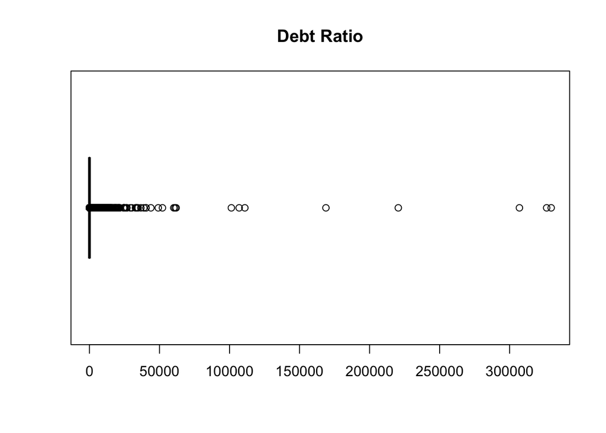

```r
boxplot(cs.training$DebtRatio, main="Debt Ratio", horizontal = T)
```

```r
outlier(cs.training$DebtRatio)
```

```
## [1] 329664
```

Let’s look at this row:

```r
cs.training[cs.training$DebtRatio == outlier(cs.training$DebtRatio),]   %>% kable()
```

[output not shown]

```r
length(boxplot.stats(cs.training$DebtRatio)$out)   # 31311 outliers in DebtRatio
```

```
## [1] 31311
```

```r
sum(is.na(cs.training$Income))   # 29731 NA's in Income
```

```
## [1] 29731
```

There are 31311 outliers in DebtRatio and 29731 NA’s in income. I’m going to replace the outliers with NA’s, since I have no idea what the values should be. I will deal with the outliers in part 3.

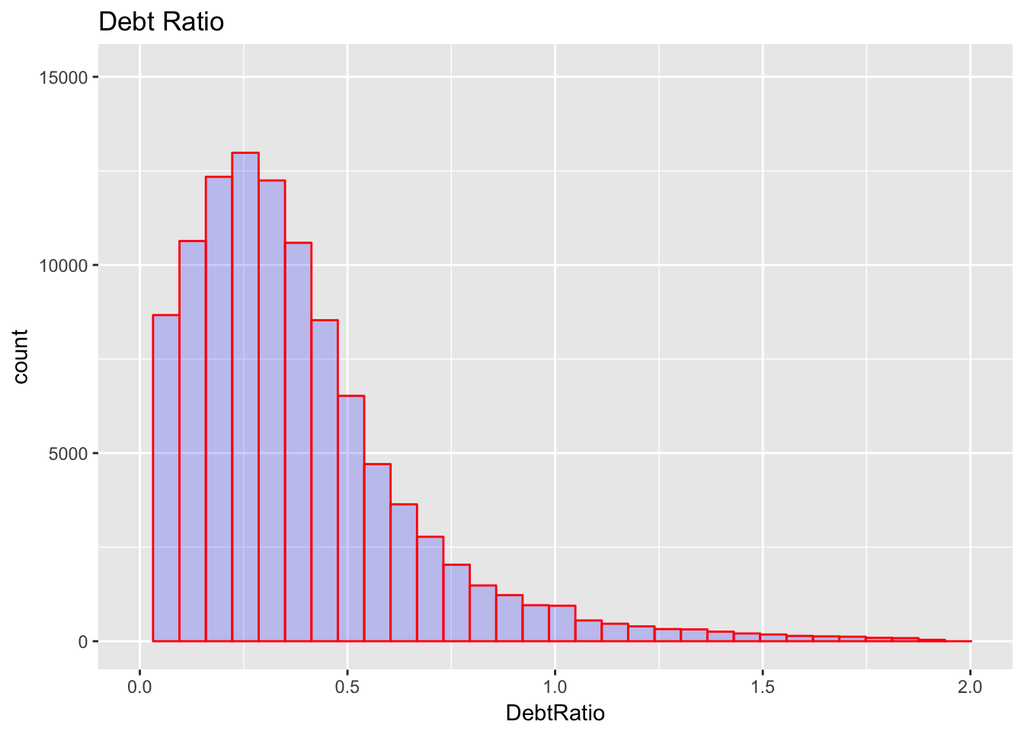

```r
DebtRatioStats <- boxplot.stats(cs.training$DebtRatio)$stats
outlierReplace(cs.training, "DebtRatio", which(cs.training$DebtRatio>DebtRatioStats[5]))
qplot(data = cs.training,
      x = DebtRatio,
      geom="histogram",
      binwidth = (DebtRatioStats[5]-DebtRatioStats[1])/30,
      main = "Debt Ratio",
      xlab = "DebtRatio",
      fill=I("blue"),
      col=I("red"),
      alpha=I(0.2),
      xlim=c(DebtRatioStats[1], DebtRatioStats[5]*1.05))
```

## 2.4 Monthly Income

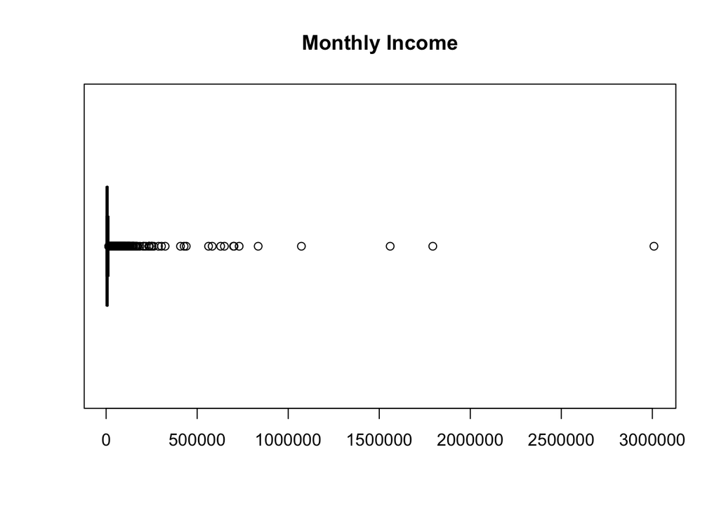

```r
boxplot(cs.training$Income, main="Monthly Income", horizontal = T)
```

```r
length(boxplot.stats(cs.training$Income)$out)   # 4879
```

```
## [1] 4879
```

```r
IncomeStats <- boxplot.stats(cs.training$Income)$stats
data.table(stats=c('min','lower quartile','median','upper quartile','max'),
           value=IncomeStats)   %>% kable()
```

[output not shown]

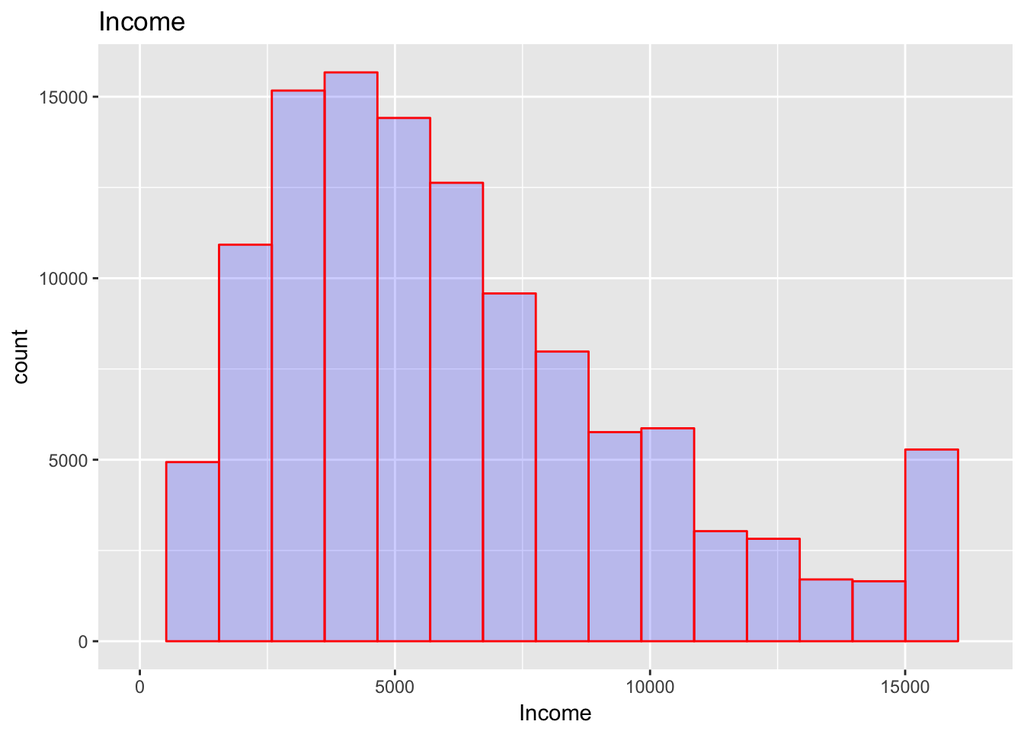

```r
outlierReplace(cs.training, "Income", which(cs.training$Income>IncomeStats[5]), IncomeStats[5])
qplot(data = cs.training,
      x = Income,
      geom="histogram",
      binwidth = (IncomeStats[5]-IncomeStats[1])/15,
      main = "Income",
      xlab = "Income",
      fill=I("blue"),
      col=I("red"),
      alpha=I(0.2),
      xlim=c(IncomeStats[1], IncomeStats[5]*1.05))
```

## 2.5 Number of Open loans and Lines of credit

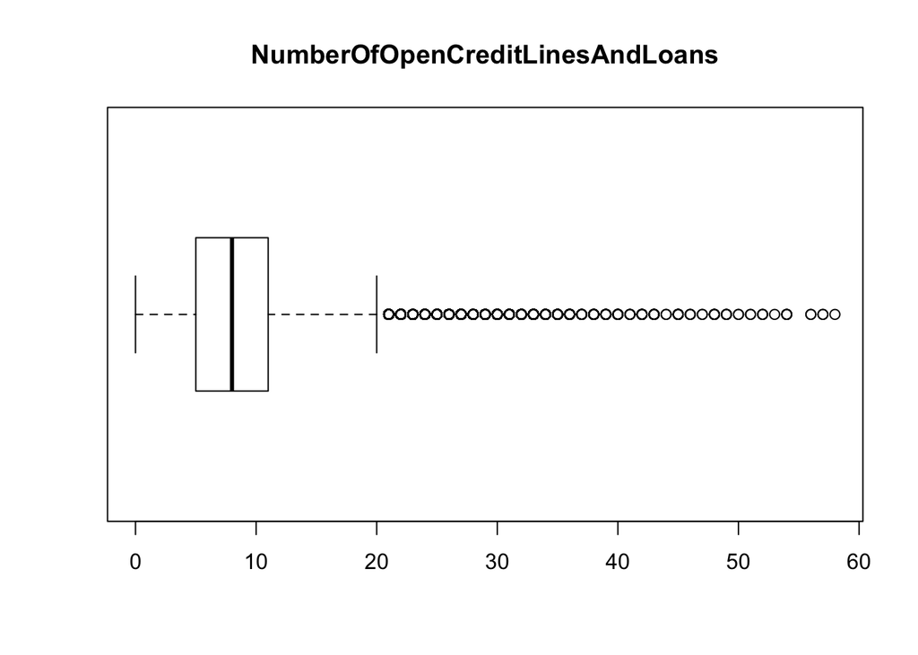

```r
  boxplot(cs.training$OpenCredit, main="NumberOfOpenCreditLinesAndLoans", horizontal = T)
```

```r
length(boxplot.stats(cs.training$OpenCredit)$out)
```

```
## [1] 3980
```

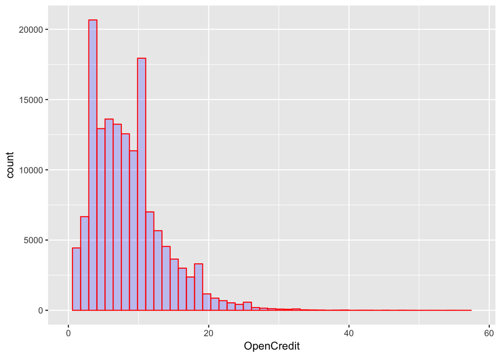

```r
qplot(data = cs.training,
      x = OpenCredit,
      geom="histogram",
      binwidth = (max(cs.training$OpenCredit)-min(cs.training$OpenCredit))/50,
      xlab = "OpenCredit",
      fill=I("blue"),
      col=I("red"),
      alpha=I(0.2),
      xlim=c(min(cs.training$OpenCredit), max(cs.training$OpenCredit)))
```

## 2.6 Number of mortgage and real estate loans including home equity lines of credit

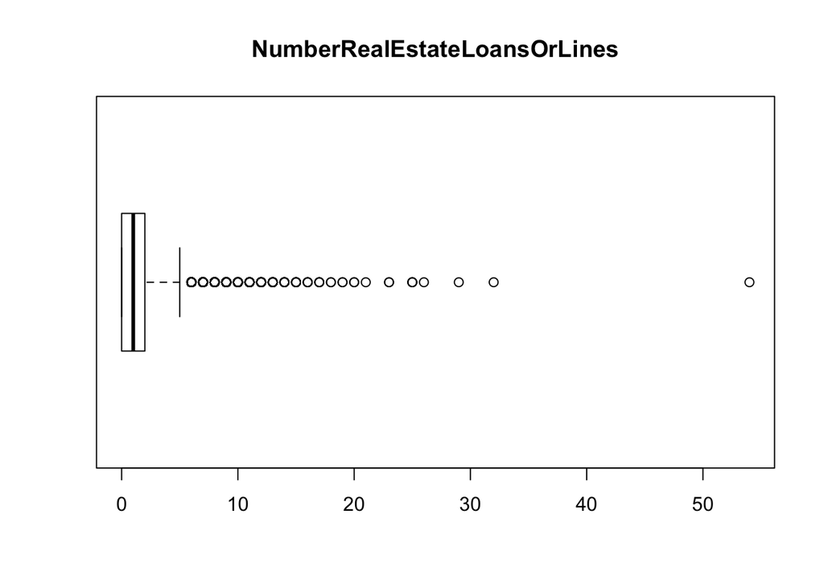

```r
  boxplot(cs.training$REloans, main="NumberRealEstateLoansOrLines", horizontal = T)
```

```r
length(boxplot.stats(cs.training$REloans)$out)   # 793
```

```
## [1] 793
```

```r
head(sort(cs.training$REloans, decreasing = T), 15)
```

```
##  [1] 54 32 29 26 25 25 25 23 23 21 20 20 19 19 18
```

```r
cs.training[cs.training$REloans == outlier(cs.training$REloans),]   %>% kable()
```

| id | SD | Age | RUUL | DebtRatio | Income | OpenCredit | REloans | Dep | no3059 | no6089 | no90 |
| --- | --- | --- | --- | --- | --- | --- | --- | --- | --- | --- | --- |
| 30588 | 0 | 53 | 0.0030322 | NA | 8000 | 58 | 54 | 0 | 0 | 0 | 0 |

```r
REloansStats <- boxplot.stats(cs.training$REloans)$stats
outlierReplace(cs.training, "REloans", which(cs.training$REloans>20), 20)
```

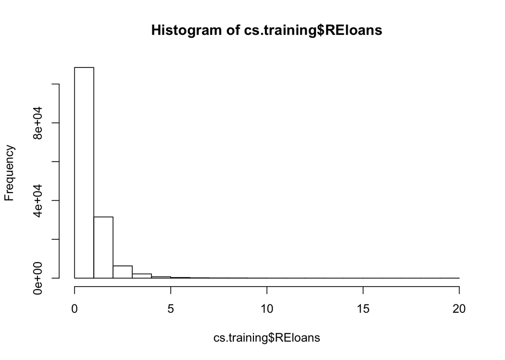

```r
hist(cs.training$REloans, breaks=20)
```

## 2.7 Number of dependents in family excluding themselves (spouse, children etc.)

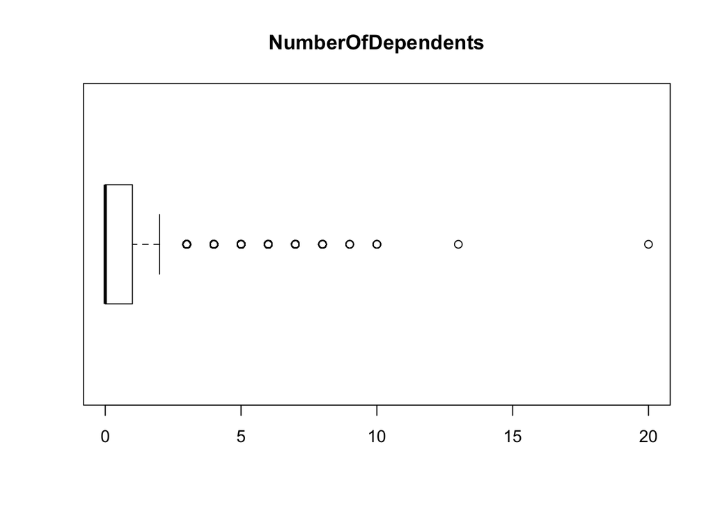

```r
  boxplot(cs.training$Dep, main="NumberOfDependents", horizontal = T)
```

```r
length(boxplot.stats(cs.training$Dep)$out)
```

```
## [1] 13336
```

```r
head(sort(cs.training$Dep, decreasing = T), 10)
```

```
##  [1] 20 13 10 10 10 10 10  9  9  9
```

```r
outlierReplace(cs.training, "Dep", which(cs.training$Dep>10), 10)
```

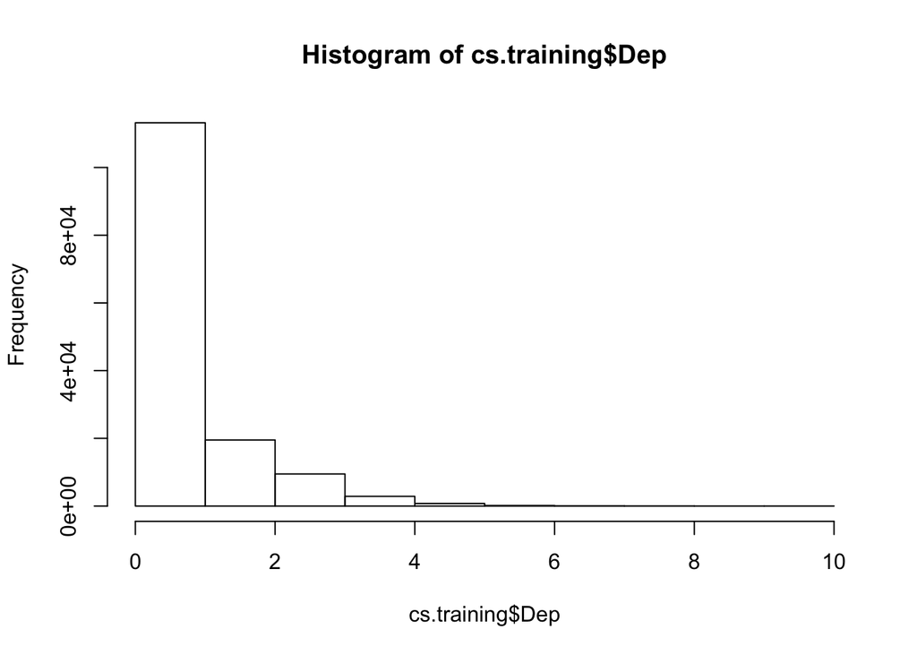

```r
  hist(cs.training$Dep, breaks=10)
```

## 2.8 Number of times borrower has been 30-59 days past due but no worse in the last 2 years

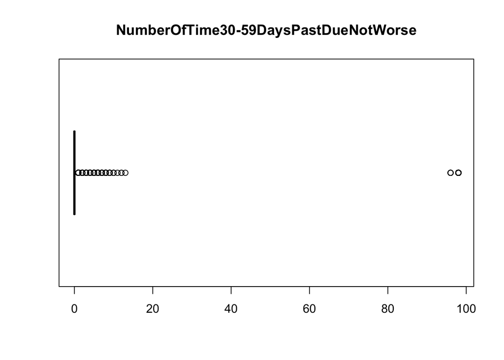

```r
  boxplot(cs.training$no3059, main="NumberOfTime30-59DaysPastDueNotWorse", horizontal = T)
```

The large values most be errors (the theoretical maximum would be 24). We see the same in no6089 and no90, so this most be some systematic (coded) error.

```r
head(sort(cs.training$no3059, decreasing = T), 100)
```

```
##   [1] 98 98 98 98 98 98 98 98 98 98 98 98 98 98 98 98 98 98 98 98 98 98 98
##  [24] 98 98 98 98 98 98 98 98 98 98 98 98 98 98 98 98 98 98 98 98 98 98 98
##  [47] 98 98 98 98 98 98 98 98 98 98 98 98 98 98 98 98 98 98 98 98 98 98 98
##  [70] 98 98 98 98 98 98 98 98 98 98 98 98 98 98 98 98 98 98 98 98 98 98 98
##  [93] 98 98 98 98 98 98 98 98
```

These values need to be replaced so that their large quantitative values do not skew the entire dataset. I will replace them by 0.

```r
outlierReplace(cs.training, "no3059", which(cs.training$no3059>20), 0)
max(cs.training$no3059)
```

```
## [1] 13
```

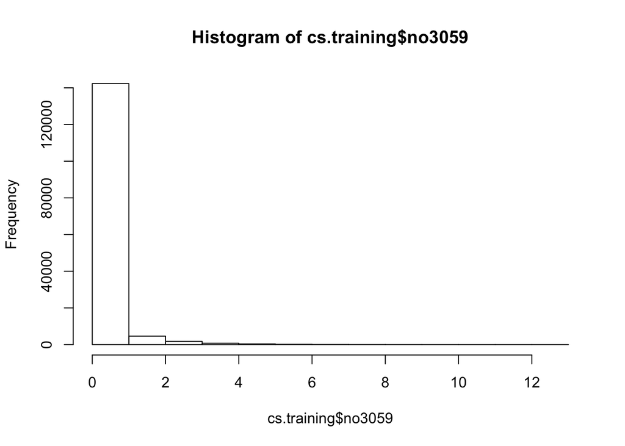

```r
  hist(cs.training$no3059, breaks=13)
```

## 2.9 Number of times borrower has been 60-89 days past due but no worse in the last 2 years

```r
outlierReplace(cs.training, "no6089", which(cs.training$no6089>20), 0)
max(cs.training$no6089)
```

```
## [1] 11
```

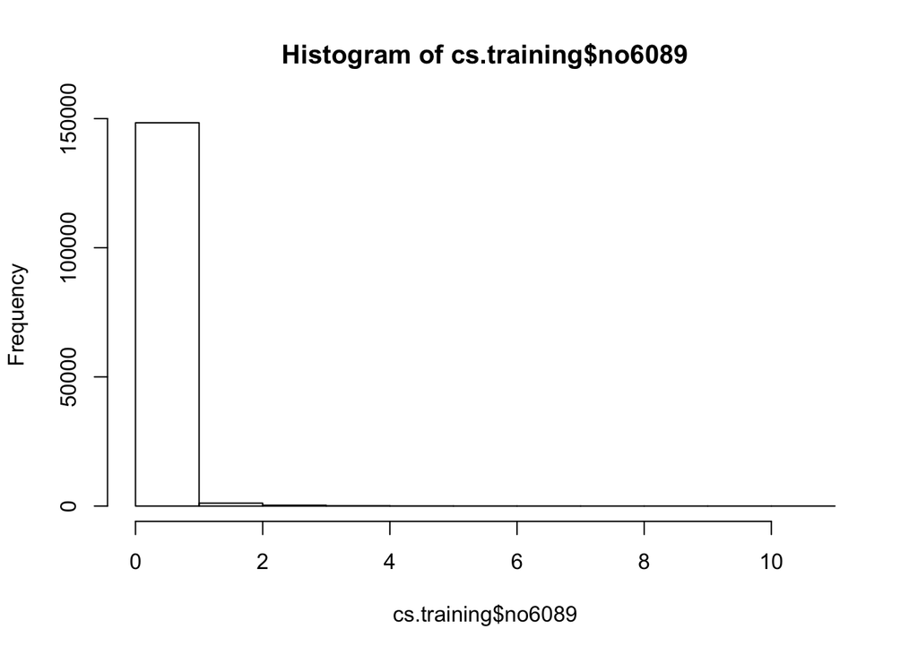

```r
  hist(cs.training$no6089, breaks=11)
```

## 2.10 Number of times borrower has been 90 days or more past due

```r
outlierReplace(cs.training, "no90", which(cs.training$no90>20), 0)
max(cs.training$no90)
```

```
## [1] 17
```

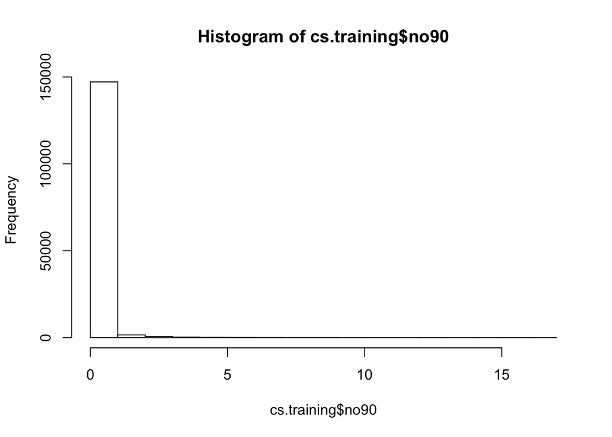

```r
  hist(cs.training$no90, breaks=17)
```

## 2.11 Summary of modified dataset

```r
summary(cs.training)
```

```
##        id               SD               Age             RUUL
##  Min.   :     1   Min.   :0.00000   Min.   : 21.0   Min.   :0.00000
##  1st Qu.: 37501   1st Qu.:0.00000   1st Qu.: 41.0   1st Qu.:0.02987
##  Median : 75000   Median :0.00000   Median : 52.0   Median :0.15418
##  Mean   : 75000   Mean   :0.06684   Mean   : 52.3   Mean   :0.32226
##  3rd Qu.:112500   3rd Qu.:0.00000   3rd Qu.: 63.0   3rd Qu.:0.55905
##  Max.   :150000   Max.   :1.00000   Max.   :109.0   Max.   :1.35216
##
##    DebtRatio         Income        OpenCredit        REloans
##  Min.   :0.000   Min.   :    0   Min.   : 0.000   Min.   : 0.000
##  1st Qu.:0.132   1st Qu.: 3400   1st Qu.: 5.000   1st Qu.: 0.000
##  Median :0.284   Median : 5400   Median : 8.000   Median : 1.000
##  Mean   :0.335   Mean   : 6158   Mean   : 8.453   Mean   : 1.018
##  3rd Qu.:0.460   3rd Qu.: 8249   3rd Qu.:11.000   3rd Qu.: 2.000
##  Max.   :1.907   Max.   :15520   Max.   :58.000   Max.   :20.000
##  NA's   :31311   NA's   :29731
##       Dep             no3059            no6089              no90
##  Min.   : 0.000   Min.   : 0.0000   Min.   : 0.00000   Min.   : 0.00000
##  1st Qu.: 0.000   1st Qu.: 0.0000   1st Qu.: 0.00000   1st Qu.: 0.00000
##  Median : 0.000   Median : 0.0000   Median : 0.00000   Median : 0.00000
##  Mean   : 0.757   Mean   : 0.2454   Mean   : 0.06471   Mean   : 0.09029
##  3rd Qu.: 1.000   3rd Qu.: 0.0000   3rd Qu.: 0.00000   3rd Qu.: 0.00000
##  Max.   :10.000   Max.   :13.0000   Max.   :11.00000   Max.   :17.00000
##  NA's   :3924
```

# 3. Detectar e imputar los NAs.

```r
sum(is.na(cs.training))   # 64966
```

```
## [1] 64966
```

```r
sum(is.na(cs.training$DebtRatio))   # 31311; introduced above by replacing outliers
```

```
## [1] 31311
```

```r
sum(is.na(cs.training$Income))   # 29731
```

```
## [1] 29731
```

```r
sum(is.na(cs.training$Dep))   # 3924
```

```
## [1] 3924
```

# 3.1 Imputate Income and Number of Dependents with mean

There are several ways to impute NA values, which we didn’t get into much. I am going to replace NA’s in Income and Dep with the (new) mean values (converted to integers to keep the same datatype), see summary above, because those values seem to be missing at random.

```r
cs.training$Income[is.na(cs.training$Income)] <- as.integer(mean(cs.training$Income, na.rm=TRUE))
cs.training$Dep[is.na(cs.training$Dep)] <- as.integer(mean(cs.training$Dep, na.rm=TRUE))
```

# 3.2 Imputate DeptRatio with knn

The NA values in DeptRatio were introced by removing outliers. I will replace these values by looking at similar cases, i.e. imputing with knn. I will remove the id column before imputation, as well as the SD values, since these are the values we want to predict.

```r
# cs.training.temp <- as.data.frame(cs.training[, -c("id", "SD")])
# preProcValues <- preProcess(cs.training.temp, method = c("knnImpute"))
# trainImputed <- predict(preProcValues, cs.training.temp)
```

This takes a very long time because the dataset is large! I will impute with mean to continue.

```r
cs.training$DebtRatio[is.na(cs.training$DebtRatio)] <- mean(cs.training$DebtRatio, na.rm=TRUE)
```

## 3.3 Summary of imputed dataset

```r
summary(cs.training)
```

```
##        id               SD               Age             RUUL
##  Min.   :     1   Min.   :0.00000   Min.   : 21.0   Min.   :0.00000
##  1st Qu.: 37501   1st Qu.:0.00000   1st Qu.: 41.0   1st Qu.:0.02987
##  Median : 75000   Median :0.00000   Median : 52.0   Median :0.15418
##  Mean   : 75000   Mean   :0.06684   Mean   : 52.3   Mean   :0.32226
##  3rd Qu.:112500   3rd Qu.:0.00000   3rd Qu.: 63.0   3rd Qu.:0.55905
##  Max.   :150000   Max.   :1.00000   Max.   :109.0   Max.   :1.35216
##    DebtRatio          Income        OpenCredit        REloans
##  Min.   :0.0000   Min.   :    0   Min.   : 0.000   Min.   : 0.000
##  1st Qu.:0.1751   1st Qu.: 3903   1st Qu.: 5.000   1st Qu.: 0.000
##  Median :0.3349   Median : 6157   Median : 8.000   Median : 1.000
##  Mean   :0.3349   Mean   : 6157   Mean   : 8.453   Mean   : 1.018
##  3rd Qu.:0.4039   3rd Qu.: 7400   3rd Qu.:11.000   3rd Qu.: 2.000
##  Max.   :1.9068   Max.   :15520   Max.   :58.000   Max.   :20.000
##       Dep              no3059            no6089              no90
##  Min.   : 0.0000   Min.   : 0.0000   Min.   : 0.00000   Min.   : 0.00000
##  1st Qu.: 0.0000   1st Qu.: 0.0000   1st Qu.: 0.00000   1st Qu.: 0.00000
##  Median : 0.0000   Median : 0.0000   Median : 0.00000   Median : 0.00000
##  Mean   : 0.7373   Mean   : 0.2454   Mean   : 0.06471   Mean   : 0.09029
##  3rd Qu.: 1.0000   3rd Qu.: 0.0000   3rd Qu.: 0.00000   3rd Qu.: 0.00000
##  Max.   :10.0000   Max.   :13.0000   Max.   :11.00000   Max.   :17.00000
```

# 4. Generar nuevas variables o features que os parezcan interesantes para el problema.

##4.1 Total number of late days A new feature could be the total number of late days.  
For example client1, who was 2 times between 30 and 60 days late (I will take the minimum), will have a total number of at least 30+30=60.  
Cient3, who was 1 time between 30 and 60 days late and 1 time 90 or more, will have a total number of at least 30+90=120.

```r
cs.training$LateDays <- cs.training[,no3059] * 30 +
                      cs.training[,no6089] * 60 +
                      cs.training[,no90] * 90
```

##4.2 log(Income) The differences in income probably will not be linearly correlated with SD, so maybe the logarithm will be a better estimate.  
An income of 0 will be a problem here. How many such cases are there?

```r
sum(cs.training$Income==0)   # 1634
```

```
## [1] 1634
```

I will replace those be the mean value, just like NA’s above.

```r
cs.training$Income[cs.training$Income==0] = as.integer(mean(cs.training$Income))
cs.training$logIncome <- log(cs.training[,Income])
```

##4.3 Debt From DeptRatio and Income we could compute the Debt:

```r
cs.training$Debt <- cs.training[,DebtRatio] * cs.training[,Income]
```

##4.4 Difference between Income and Dept Maybe a good indicator would be what people have left when they subtract their debt from their income (note: the result can be negative as well). I will call this Slack

```r
cs.training$Slack <- cs.training[,Income] - cs.training[,Debt]
```

##4.5 Look at the training set with the new variables

```r
summary(cs.training)
```

```
##        id               SD               Age             RUUL
##  Min.   :     1   Min.   :0.00000   Min.   : 21.0   Min.   :0.00000
##  1st Qu.: 37501   1st Qu.:0.00000   1st Qu.: 41.0   1st Qu.:0.02987
##  Median : 75000   Median :0.00000   Median : 52.0   Median :0.15418
##  Mean   : 75000   Mean   :0.06684   Mean   : 52.3   Mean   :0.32226
##  3rd Qu.:112500   3rd Qu.:0.00000   3rd Qu.: 63.0   3rd Qu.:0.55905
##  Max.   :150000   Max.   :1.00000   Max.   :109.0   Max.   :1.35216
##    DebtRatio          Income        OpenCredit        REloans
##  Min.   :0.0000   Min.   :    1   Min.   : 0.000   Min.   : 0.000
##  1st Qu.:0.1751   1st Qu.: 4000   1st Qu.: 5.000   1st Qu.: 0.000
##  Median :0.3349   Median : 6157   Median : 8.000   Median : 1.000
##  Mean   :0.3349   Mean   : 6224   Mean   : 8.453   Mean   : 1.018
##  3rd Qu.:0.4039   3rd Qu.: 7400   3rd Qu.:11.000   3rd Qu.: 2.000
##  Max.   :1.9068   Max.   :15520   Max.   :58.000   Max.   :20.000
##       Dep              no3059            no6089              no90
##  Min.   : 0.0000   Min.   : 0.0000   Min.   : 0.00000   Min.   : 0.00000
##  1st Qu.: 0.0000   1st Qu.: 0.0000   1st Qu.: 0.00000   1st Qu.: 0.00000
##  Median : 0.0000   Median : 0.0000   Median : 0.00000   Median : 0.00000
##  Mean   : 0.7373   Mean   : 0.2454   Mean   : 0.06471   Mean   : 0.09029
##  3rd Qu.: 1.0000   3rd Qu.: 0.0000   3rd Qu.: 0.00000   3rd Qu.: 0.00000
##  Max.   :10.0000   Max.   :13.0000   Max.   :11.00000   Max.   :17.00000
##     LateDays         logIncome          Debt             Slack
##  Min.   :   0.00   Min.   :0.000   Min.   :    0.0   Min.   :-13377
##  1st Qu.:   0.00   1st Qu.:8.294   1st Qu.:  780.6   1st Qu.:  2433
##  Median :   0.00   Median :8.725   Median : 2061.9   Median :  4095
##  Mean   :  19.37   Mean   :8.553   Mean   : 1965.1   Mean   :  4259
##  3rd Qu.:   0.00   3rd Qu.:8.909   3rd Qu.: 2451.7   3rd Qu.:  5298
##  Max.   :1530.00   Max.   :9.650   Max.   :28897.4   Max.   : 15520
```

# 5. Identificar y eliminar las variables correladas.

## 5.1 Correlation Matrix and Correlation Plot

```r
M <- cor(cs.training[,-"id",with=F], use = "pairwise.complete.obs")
round(M,2)   %>% kable()
```

|  | SD | Age | RUUL | DebtRatio | Income | OpenCredit | REloans | Dep | no3059 | no6089 | no90 | LateDays | logIncome | Debt | Slack |
| --- | --- | --- | --- | --- | --- | --- | --- | --- | --- | --- | --- | --- | --- | --- | --- |
| SD | 1.00 | -0.12 | 0.28 | 0.06 | -0.06 | -0.03 | -0.01 | 0.05 | 0.27 | 0.27 | 0.31 | 0.39 | -0.04 | 0.02 | -0.08 |
| Age | -0.12 | 1.00 | -0.28 | -0.05 | 0.10 | 0.15 | 0.03 | -0.22 | -0.07 | -0.07 | -0.08 | -0.10 | 0.11 | 0.01 | 0.11 |
| RUUL | 0.28 | -0.28 | 1.00 | 0.12 | -0.10 | -0.16 | -0.07 | 0.09 | 0.24 | 0.20 | 0.25 | 0.32 | -0.08 | 0.06 | -0.15 |
| DebtRatio | 0.06 | -0.05 | 0.12 | 1.00 | -0.14 | 0.29 | 0.43 | 0.07 | 0.09 | 0.04 | 0.00 | 0.04 | -0.10 | 0.64 | -0.52 |
| Income | -0.06 | 0.10 | -0.10 | -0.14 | 1.00 | 0.25 | 0.34 | 0.18 | -0.01 | -0.04 | -0.06 | -0.06 | 0.75 | 0.49 | 0.87 |
| OpenCredit | -0.03 | 0.15 | -0.16 | 0.29 | 0.25 | 1.00 | 0.44 | 0.07 | 0.08 | -0.02 | -0.09 | -0.04 | 0.19 | 0.42 | 0.05 |
| REloans | -0.01 | 0.03 | -0.07 | 0.43 | 0.34 | 0.44 | 1.00 | 0.13 | 0.04 | -0.02 | -0.06 | -0.04 | 0.24 | 0.64 | 0.03 |
| Dep | 0.05 | -0.22 | 0.09 | 0.07 | 0.18 | 0.07 | 0.13 | 1.00 | 0.07 | 0.04 | 0.03 | 0.06 | 0.11 | 0.16 | 0.11 |
| no3059 | 0.27 | -0.07 | 0.24 | 0.09 | -0.01 | 0.08 | 0.04 | 0.07 | 1.00 | 0.31 | 0.22 | 0.58 | 0.00 | 0.08 | -0.05 |
| no6089 | 0.27 | -0.07 | 0.20 | 0.04 | -0.04 | -0.02 | -0.02 | 0.04 | 0.31 | 1.00 | 0.29 | 0.63 | -0.02 | 0.01 | -0.05 |
| no90 | 0.31 | -0.08 | 0.25 | 0.00 | -0.06 | -0.09 | -0.06 | 0.03 | 0.22 | 0.29 | 1.00 | 0.87 | -0.04 | -0.04 | -0.05 |
| LateDays | 0.39 | -0.10 | 0.32 | 0.04 | -0.06 | -0.04 | -0.04 | 0.06 | 0.58 | 0.63 | 0.87 | 1.00 | -0.03 | 0.00 | -0.07 |
| logIncome | -0.04 | 0.11 | -0.08 | -0.10 | 0.75 | 0.19 | 0.24 | 0.11 | 0.00 | -0.02 | -0.04 | -0.03 | 1.00 | 0.40 | 0.63 |
| Debt | 0.02 | 0.01 | 0.06 | 0.64 | 0.49 | 0.42 | 0.64 | 0.16 | 0.08 | 0.01 | -0.04 | 0.00 | 0.40 | 1.00 | 0.00 |
| Slack | -0.08 | 0.11 | -0.15 | -0.52 | 0.87 | 0.05 | 0.03 | 0.11 | -0.05 | -0.05 | -0.05 | -0.07 | 0.63 | 0.00 | 1.00 |

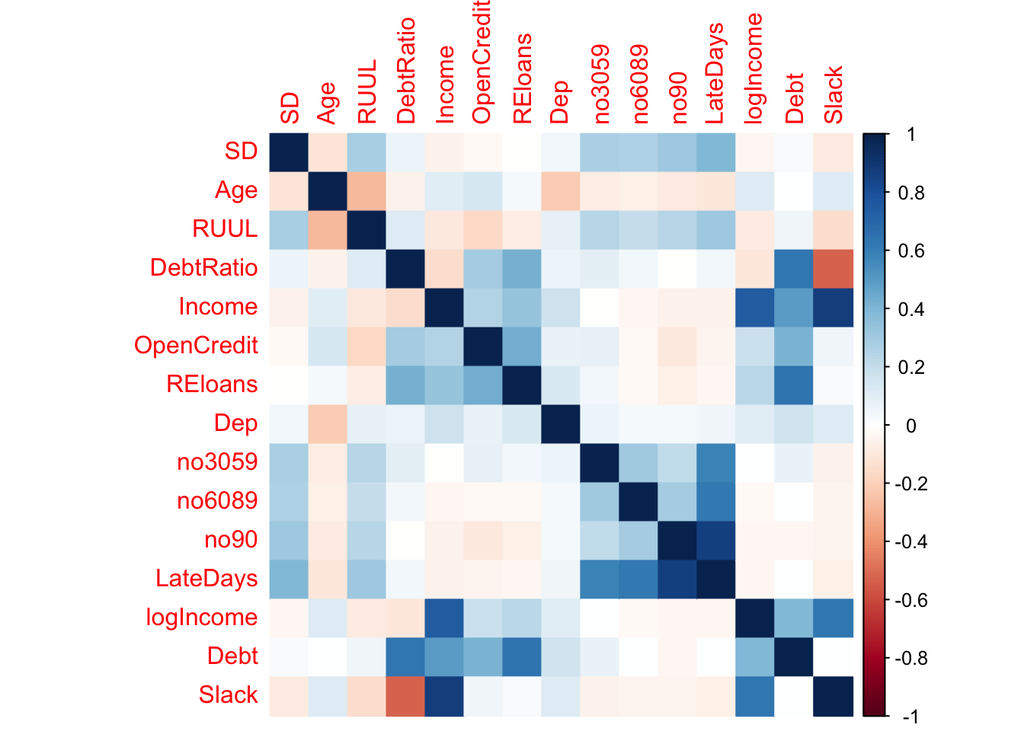

```r
corrplot(M, method="color")
```

We see that RUUL, no3059, no6089, no90 and LateDays are good predictors for SD.  
! The new variable LateDays does very well and better than just one of its components!  
And the new variable Slack does better than Income or Debt.

## 5.2 Look at and remvove correlated values

```r
highCorr  <- findCorrelation(M[-1,-1], 0.75, names=T)
highCorr   # "Income"   "LateDays"
```

```
## [1] "Income"   "LateDays"
```

?? Why remove LateDays instead of no90 ?? LateDays and no90 have a high correlation, but LateDays has a higher correlation with SD. So I will remove no90 instead.

```r
cs.training <- cs.training[, -c("Income", "no90")]
```

## 5.3 New Correlation Plot

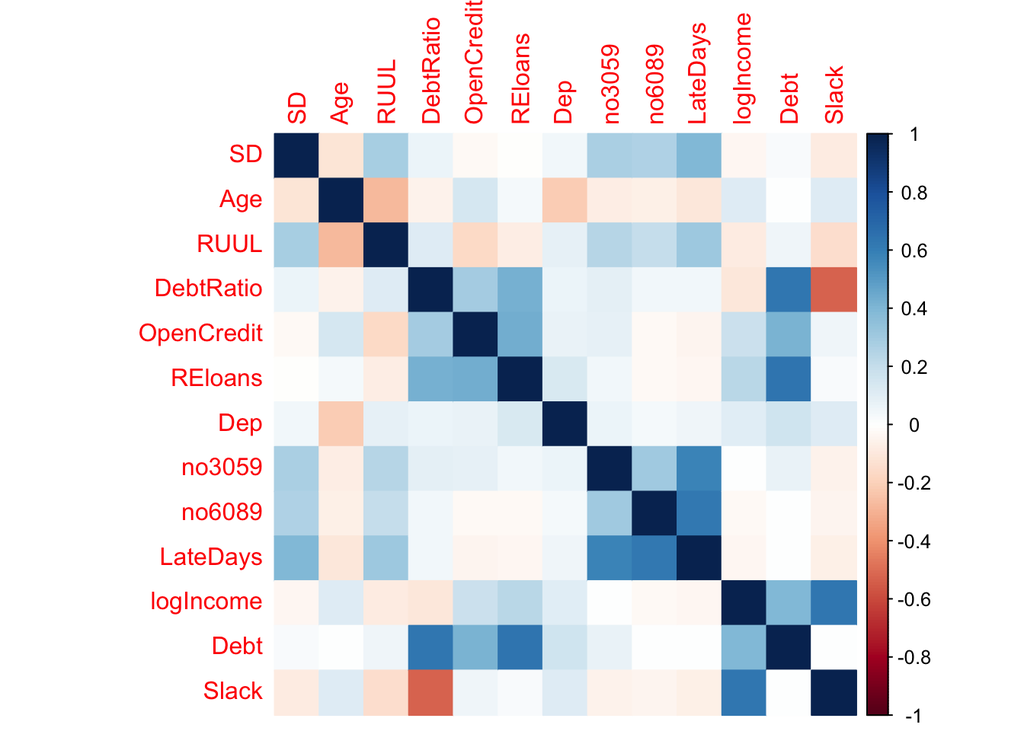

```r
M <- cor(cs.training[,-"id",with=F], use = "pairwise.complete.obs")
corrplot(M, method="color")
```

# 6. Identificar y eliminar las variables con cero varianza y varianza cercana a cero.

```r
nzv <- nearZeroVar(cs.training)
colnames(cs.training)[nzv]   # "no6089"
```

```
## [1] "no6089"
```

```r
cs.training <- cs.training[,-nzv,with=F]  # removing nzv columns
str(cs.training)
```

```
## Classes 'data.table' and 'data.frame':   150000 obs. of  13 variables:
##  $ id        : int  1 2 3 4 5 6 7 8 9 10 ...
##  $ SD        : int  1 0 0 0 0 0 0 0 0 0 ...
##  $ Age       : int  45 40 38 30 49 74 57 39 27 57 ...
##  $ RUUL      : num  0.766 0.957 0.658 0.234 0.907 ...
##  $ DebtRatio : num  0.803 0.1219 0.0851 0.036 0.0249 ...
##  $ OpenCredit: int  13 4 2 5 7 3 8 8 2 9 ...
##  $ REloans   : int  6 0 0 0 1 1 3 0 0 4 ...
##  $ Dep       : int  2 1 0 0 0 1 0 0 0 2 ...
##  $ no3059    : int  2 0 1 0 1 0 0 0 0 0 ...
##  $ LateDays  : num  60 0 120 0 30 0 0 0 0 0 ...
##  $ logIncome : num  9.12 7.86 8.02 8.1 9.65 ...
##  $ Debt      : num  7323 317 259 119 387 ...
##  $ Slack     : num  1797 2283 2783 3181 15133 ...
##  - attr(*, ".internal.selfref")=<externalptr>
```

# 7. Hacer cualquier otra transformacion con los datos que os parezca interesante.

## 7.1 Removing index

When we will use this data to build a model to predict SD, we don’t need the indices, so let’s remove them:

```r
cs.training <- cs.training[, -"id"]
```

## 7.2 Center&Scale data

Some algorithms, like linear regression and neural networks, require to normalize the data. Assuming this is necessary, I will continue to center and scale the data:

```r
trans = preProcess(cs.training[, -"SD"],
                   method=c("center", "scale"))
train_normalized = predict(trans, cs.training)
```

```r
head(train_normalized, 10)   %>% kable()
```

| SD | Age | RUUL | DebtRatio | OpenCredit | REloans | Dep | no3059 | LateDays | logIncome | Debt | Slack |
| --- | --- | --- | --- | --- | --- | --- | --- | --- | --- | --- | --- |
| 1 | -0.4939023 | 1.2448585 | 1.8402257 | 0.8836540 | 4.4647142 | 1.1416911 | 2.5165915 | 0.6509246 | 0.6966108 | 3.3016944 | -0.8600639 |
| 0 | -0.8323977 | 1.7805980 | -0.8373704 | -0.8652939 | -0.9119619 | 0.2375055 | -0.3518966 | -0.3103085 | -0.8503891 | -1.0156682 | -0.6902144 |
| 0 | -0.9677959 | 0.9421161 | -0.9818942 | -1.2539490 | -0.9119619 | -0.6666802 | 1.0823475 | 1.6121577 | -0.6568490 | -1.0513858 | -0.5155996 |
| 0 | -1.5093885 | -0.2480561 | -1.1747757 | -0.6709664 | -0.9119619 | -0.6666802 | -0.3518966 | -0.3103085 | -0.5564974 | -1.1376249 | -0.3766131 |
| 0 | -0.2231059 | 1.6406179 | -1.2185069 | -0.2823113 | -0.0158492 | -0.6666802 | 1.0823475 | 0.1703081 | 1.3519931 | -0.9725529 | 3.7977272 |
| 0 | 1.4693711 | -0.3059173 | 0.1601081 | -1.0596214 | -0.0158492 | 0.2375055 | -0.3518966 | -0.3103085 | -0.4839642 | -0.4008472 | -0.7243528 |
| 0 | 0.3184867 | -0.0464849 | 0.0000000 | -0.0879837 | 1.7763761 | -0.6666802 | -0.3518966 | -0.3103085 | 0.2123034 | 0.0596041 | -0.0573560 |
| 0 | -0.9000968 | 1.2121491 | -0.4911697 | -0.0879837 | -0.9119619 | -0.6666802 | -0.3518966 | -0.3103085 | -0.4839642 | -0.7581468 | -0.5218426 |
| 0 | -1.7124858 | -0.5757946 | 0.0000000 | -1.2539490 | -0.9119619 | -0.6666802 | -0.3518966 | -0.3103085 | 0.2123034 | 0.0596041 | -0.0573560 |
| 0 | 0.3184867 | -0.3732537 | 1.0669838 | 0.1063438 | 2.6724888 | 1.1416911 | -0.3518966 | -0.3103085 | 1.3519931 | 4.5873779 | 0.6464706 |

# 8. Almacenar los datos modificados en disco

```r
fwrite(train_normalized, file = "../dat/Train.csv")
```